# Exploration

Savannah Hammerton

10/12/2021

## Exploratory Analysis

### Getting Started

I am going to go through each important variable, exploring with both plot and print/numerical output.

To get started, first I need to load my needed packages and the data I previously cleaned. Then I’ll see what variables I have to work with to decide which ones to explore.

```r
#load needed packages
library(tidyverse) #for data processing and analysis
library(knitr) #
library(vtable) #to create summary stats table
#set data location
data_location <- here::here('data', 'processed_data', 'processeddata.rds')
#load data and set to object
data <- readRDS(data_location)
#list variables
ls(data)
```

```
##  [1] "AbPain"            "BodyTemp"          "Breathless"
##  [4] "ChestCongestion"   "ChestPain"         "ChillsSweats"
##  [7] "CoughIntensity"    "CoughYN"           "CoughYN2"
## [10] "Diarrhea"          "EarPn"             "EyePn"
## [13] "Fatigue"           "Headache"          "Hearing"
## [16] "Insomnia"          "ItchyEye"          "Myalgia"
## [19] "MyalgiaYN"         "NasalCongestion"   "Nausea"
## [22] "Pharyngitis"       "RunnyNose"         "Sneeze"
## [25] "SubjectiveFever"   "SwollenLymphNodes" "ToothPn"
## [28] "Vision"            "Vomit"             "Weakness"
## [31] "WeaknessYN"        "Wheeze"
```

```r
#set all future figuer themes
theme_set(theme_light())
```

The main outcomes we’ll be looking at are **body temperature** and **nausea**, so I’ll definitely be exploring those. I’ll also explore **runny nose**, **subjective fever**, **cough intensity**, and **vomiting**. I’ll go through these one by one and explore each before moving on to the next.

### Summary of All Variables

First, I’ll get a quick summary table of all the variables and their descriptive statistics.

```r
#summary stats table of all variables
st(data)
```

Summary Statistics

| Variable | N | Mean | Std. Dev. | Min | Pctl. 25 | Pctl. 75 | Max |
| --- | --- | --- | --- | --- | --- | --- | --- |
| SwollenLymphNodes | 730 |  |  |  |  |  |  |
| … No | 418 | 57.3% |  |  |  |  |  |
| … Yes | 312 | 42.7% |  |  |  |  |  |
| ChestCongestion | 730 |  |  |  |  |  |  |
| … No | 323 | 44.2% |  |  |  |  |  |
| … Yes | 407 | 55.8% |  |  |  |  |  |
| ChillsSweats | 730 |  |  |  |  |  |  |
| … No | 130 | 17.8% |  |  |  |  |  |
| … Yes | 600 | 82.2% |  |  |  |  |  |
| NasalCongestion | 730 |  |  |  |  |  |  |
| … No | 167 | 22.9% |  |  |  |  |  |
| … Yes | 563 | 77.1% |  |  |  |  |  |
| CoughYN | 730 |  |  |  |  |  |  |
| … No | 75 | 10.3% |  |  |  |  |  |
| … Yes | 655 | 89.7% |  |  |  |  |  |
| Sneeze | 730 |  |  |  |  |  |  |
| … No | 339 | 46.4% |  |  |  |  |  |
| … Yes | 391 | 53.6% |  |  |  |  |  |
| Fatigue | 730 |  |  |  |  |  |  |
| … No | 64 | 8.8% |  |  |  |  |  |
| … Yes | 666 | 91.2% |  |  |  |  |  |
| SubjectiveFever | 730 |  |  |  |  |  |  |
| … No | 230 | 31.5% |  |  |  |  |  |
| … Yes | 500 | 68.5% |  |  |  |  |  |
| Headache | 730 |  |  |  |  |  |  |
| … No | 115 | 15.8% |  |  |  |  |  |
| … Yes | 615 | 84.2% |  |  |  |  |  |
| Weakness | 730 |  |  |  |  |  |  |
| … None | 49 | 6.7% |  |  |  |  |  |
| … Mild | 223 | 30.5% |  |  |  |  |  |

[output cut: 70 more lines]

This is a great quick table that gives all variables, the response proportions for categorical variables, and summary statistics for the continuous variable. For the variables I’ve chosen to focus on, I can see:

- **Body temperature**: The mean response was 98.94 degrees Fahrenheit with a standard deviation of 1.196. Values ranged from 97.2 to 103.1, with an interquartile range (IQR) 98.2 to 99.3.
- **Nausea**: All 730 observations have nausea data. 255 (34.9%) of those experienced nausea, and 475 (65.1%) did not.
- **Runny nose**: All 730 observations have runny nose data. 519 (71.1%) of those experienced a runny nose, and 211 (28.9%) did not.
- **Subjective fever**: All 730 observations have subjective fever data. 500 (68.5%) of those experienced subjective fever, and 230 (31.5%) did not.
- **Cough intensity**: All 730 observations have cough intensity data. 47 (6.4%) of those did *not* experience cough, 154 (21.1%) experienced *mild* cough, 357 (48.9%) experienced *moderate* cough, and 172 (23.6%) experienced *severe* cough.
- **Vomiting**: All 730 observations have vomiting data. 78 (10.7%) of those did experience vomiting, and 652 (89.3%) did not.

### Body Temperature

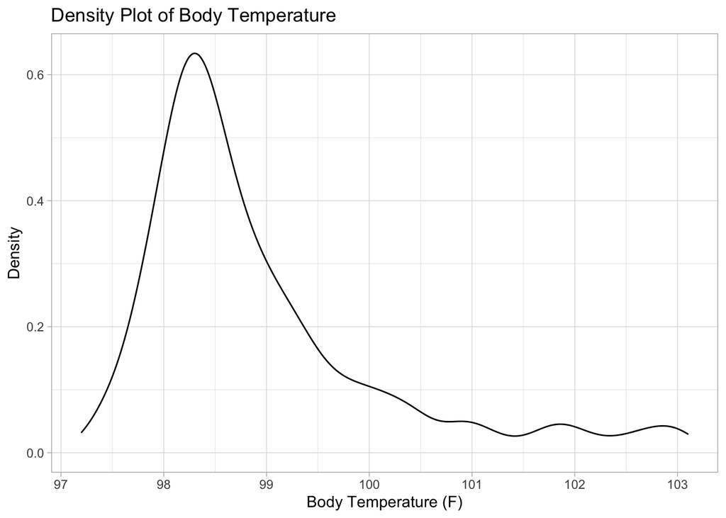

```r
#density plot of body temp
ggplot(data, aes(x = BodyTemp)) +
  geom_density() +
  labs(x = 'Body Temperature (F)', y = 'Density',
       title = 'Density Plot of Body Temperature')
```

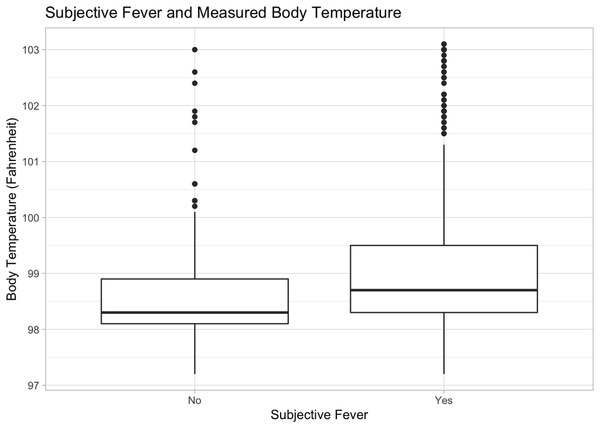

```r
#boxplot of subject fever versus actual body temperature
ggplot(data, aes(x = SubjectiveFever, y = BodyTemp)) +
  geom_boxplot() +
  labs(x = 'Subjective Fever', y = 'Body Temperature (Fahrenheit)',
       title = 'Subjective Fever and Measured Body Temperature')
```

```r
#mean body temp with and without subjective fever
data %>%
  dplyr::group_by(SubjectiveFever) %>%
  summarise(Count = n(),
            Mean_Body_Temp = mean(BodyTemp)) %>%
  kable(format = 'simple')
```

| SubjectiveFever | Count | Mean_Body_Temp |
| --- | --- | --- |
| No | 230 | 98.57391 |
| Yes | 500 | 99.10120 |

I can see from the density plot that the most of the temperature readings were around 98-99 degrees Fahrenheit. This makes sense with normal temperature being 98.6 degrees. Temperature readings range all the way to 103 degrees, but readings from around 100-103 degrees are much less frequent.

I was interested in seeing whether those who had subjective fever, or thought they had fever, typically had an actual measured fever. I created a boxplot of subjective fever and measured temperatures to see the difference. There doesn’t appear a large difference, and there’s definitely a good bit of overlap, but those with subjective fever did appear to have higher temperatures in general. This is confirmed by the mean body temps in those with and without subjective fever - the mean temperature in those with subjective fever is higher than in those without, but only slightly.

### Nausea

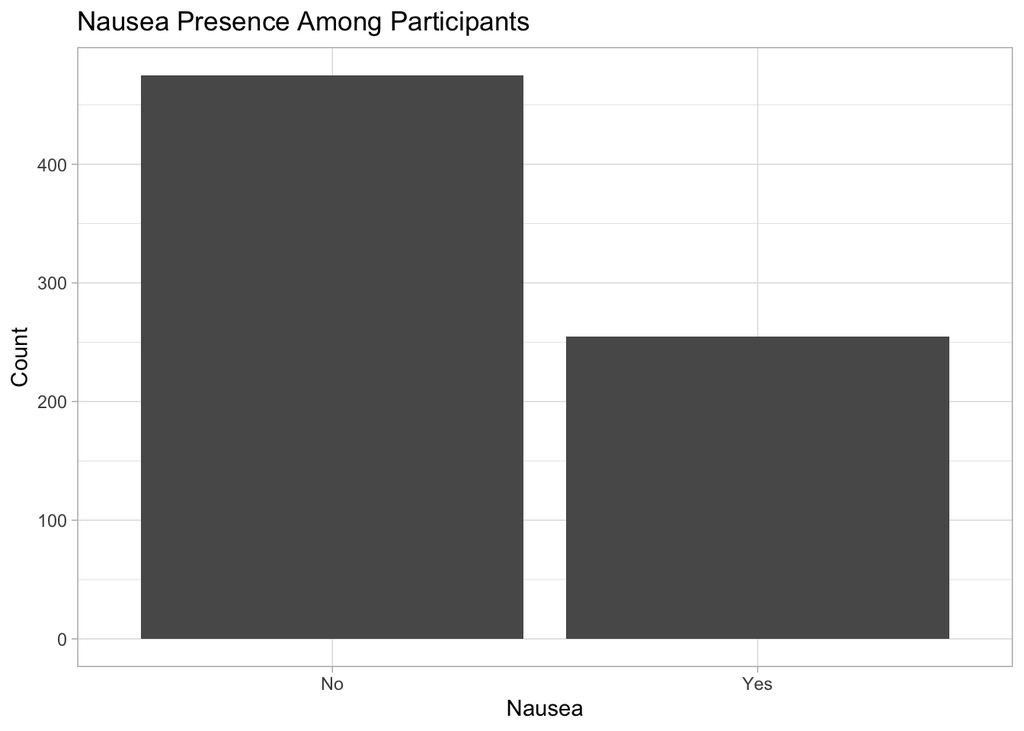

```r
#barplot of nausea presence
ggplot(data = data, aes(x = Nausea)) +
  geom_bar() +
  labs(y = 'Count', title = 'Nausea Presence Among Participants')
```

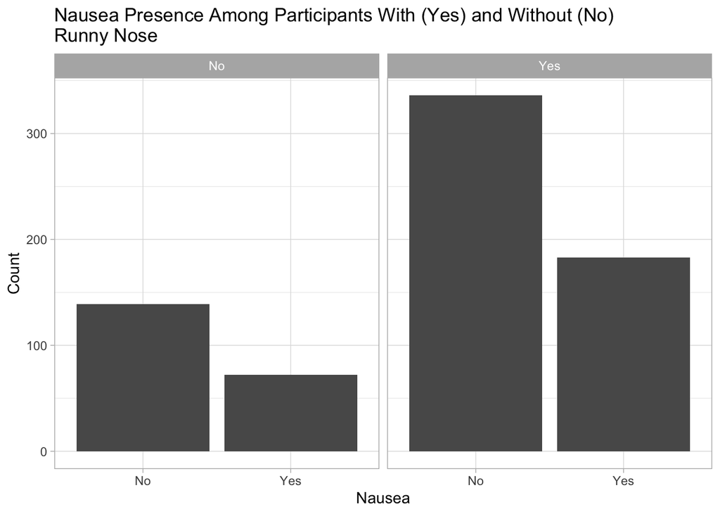

```r
#barplot of nausea presence according to runny nose
ggplot(data = data, aes(x = Nausea)) +
  geom_bar() +
  facet_wrap(vars(RunnyNose)) +
  labs(y = 'Count', title = 'Nausea Presence Among Participants With (Yes) and Without (No)\nRunny Nose')
```

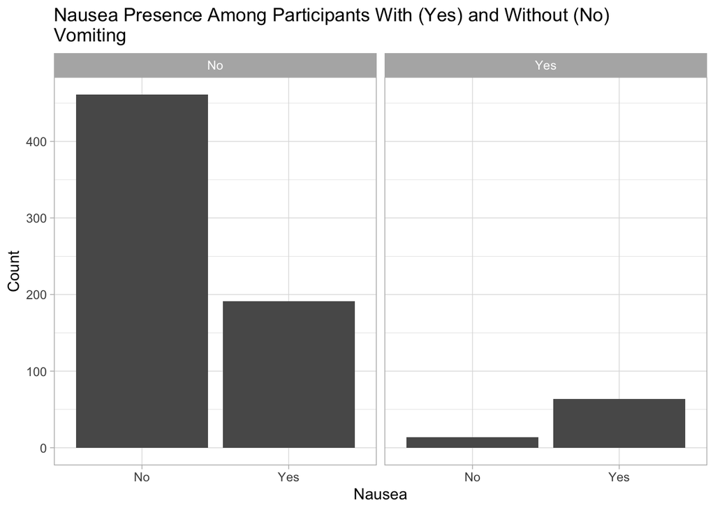

```r
#barplot of nausea presence according to vomiting
ggplot(data = data, aes(x = Nausea)) +
  geom_bar() +
  facet_wrap(vars(Vomit)) +
  labs(y = 'Count', title = 'Nausea Presence Among Participants With (Yes) and Without (No)\nVomiting')
```

For nausea, I first visualized simply how many did and did not experience nausea. The boxplot appears to mimic the summary table values of 475 without nausea and 255 with nausea.

I then looked at nausea in those with and without the runny nose symptom. While there are more participants overall who experienced a runny nose, the presence of nausea appears to be similar across those who did and did not have a runny nose.

Finally, I looked at nausea presence in those who did and did not vomit. This seemed a little obvious, but I was curious to see if the results matched what I expected (mainly, everyone who vomited would have experienced nausea). While the results mostly matched, I was surprised to see a few cases where vomiting *was* reported, but nausea was *not*. It looks like there are less than 20 of these cases, but I was still surprised to see any!

### Runny Nose

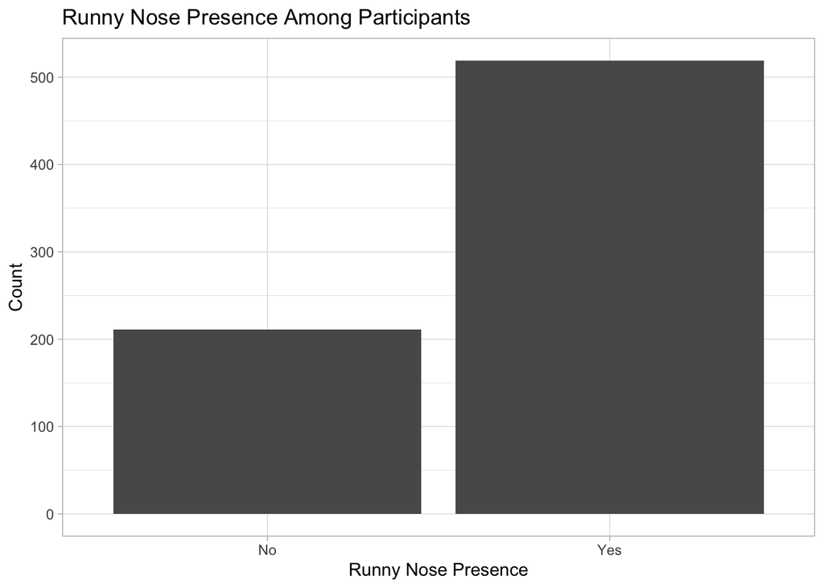

```r
#barplot of runny nose presence
ggplot(data = data, aes(x = RunnyNose)) +
  geom_bar() +
  labs(x = 'Runny Nose Presence', y = 'Count', title = 'Runny Nose Presence Among Participants')
```

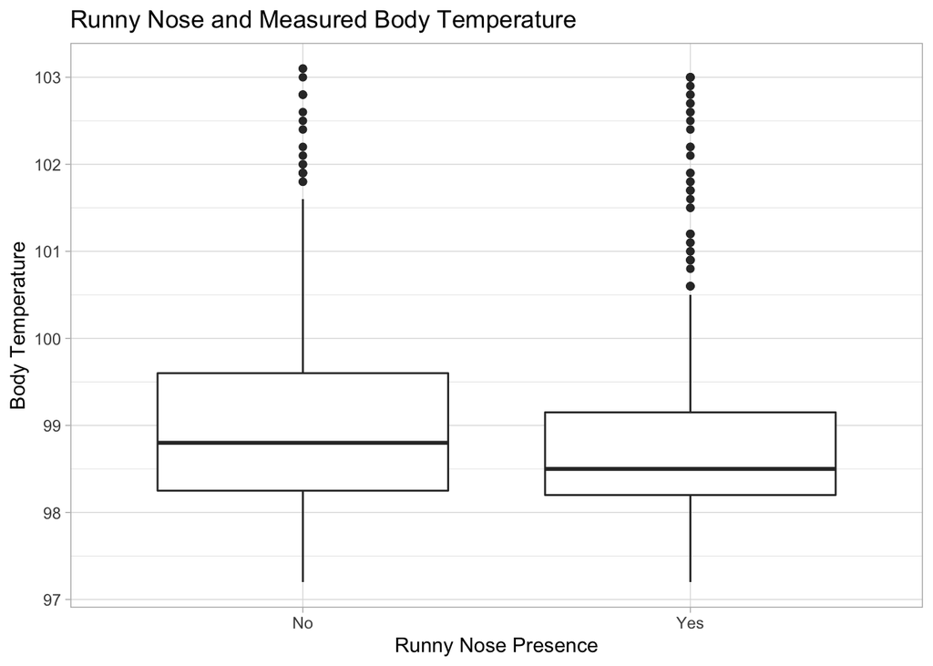

```r
#boxplot of runny nose versus body temperature
ggplot(data, aes(x = RunnyNose, y = BodyTemp)) +
  geom_boxplot() +
  labs(x = 'Runny Nose Presence', y = 'Body Temperature',
       title = 'Runny Nose and Measured Body Temperature')
```

```r
#mean body temp with and without runny nose
data %>%
  dplyr::group_by(RunnyNose) %>%
  summarise(Count = n(),
            Mean_Body_Temp = mean(BodyTemp)) %>%
  kable(format = 'simple')
```

| RunnyNose | Count | Mean_Body_Temp |
| --- | --- | --- |
| No | 211 | 99.14313 |
| Yes | 519 | 98.85048 |

Once again, I started looking at the runny nose symptom by just visualizing how many did and did not have a runny nose. Again, this matches the earlier summary table which stated 519 did have a runny nose and 211 did not.

I then looked to see the differences in body temperature in those with and without a runny nose. This boxplot looks even more similar than when I compared subjective fever and body temperature. The mean body temperatures are closer as well, with a mean temperature of 99.14 in those without runny nose and 98.85 in those with a runny nose. I was also surprised here that the mean temperature was higher in those *without* a runny nose.

### Subjective Fever

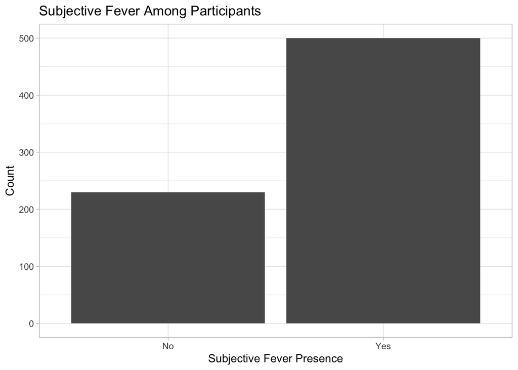

```r
#barplot of subjective fever presence
ggplot(data = data, aes(x = SubjectiveFever)) +
  geom_bar() +
  labs(x = 'Subjective Fever Presence', y = 'Count', title = 'Subjective Fever Among Participants')
```

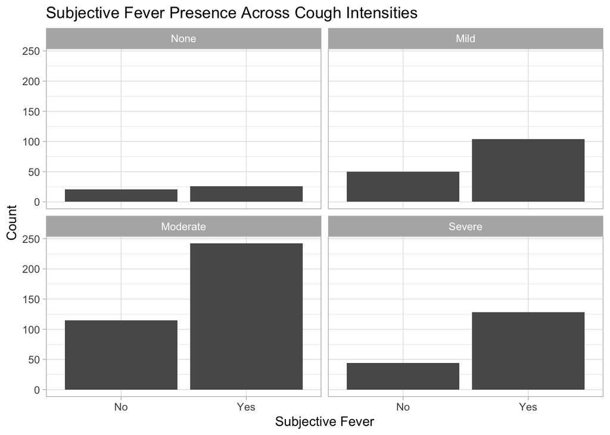

```r
#barplot of subjective fever and cough intensity
ggplot(data = data, aes(x = SubjectiveFever)) +
  geom_bar() +
  facet_wrap(vars(CoughIntensity)) +
  labs(x = 'Subjective Fever', y = 'Count',
       title = 'Subjective Fever Presence Across Cough Intensities')
```

The boxplot for subjective fever again matches the summary table, with 230 with *no* subjective fever, and 500 *with* subjective fever.

I looked to see how the distribution changed across cough intensities. In those without cough, there seem to be an almost equal amount with and without subjective fever. However, as cough intensity increases, the difference also seems to increase, with more and more participants experiencing subjective fever.

### Cough Intensity

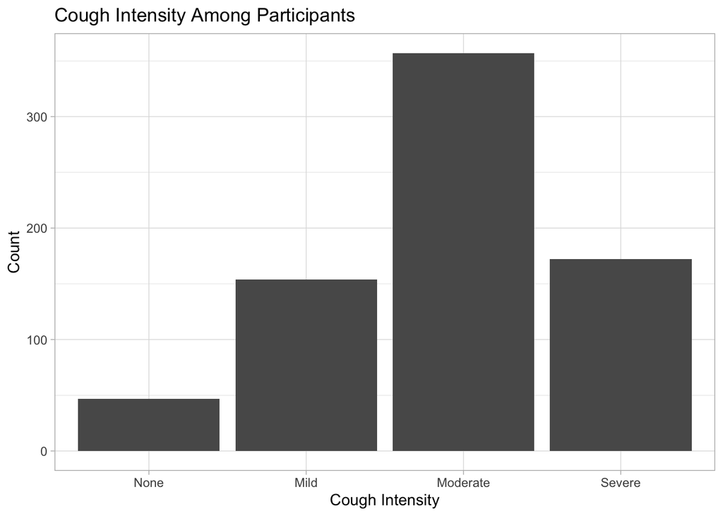

```r
#barplot of cough intensity
ggplot(data = data, aes(x = CoughIntensity)) +
  geom_bar() +
  labs(y = 'Count', x = 'Cough Intensity',
       title = 'Cough Intensity Among Participants')
```

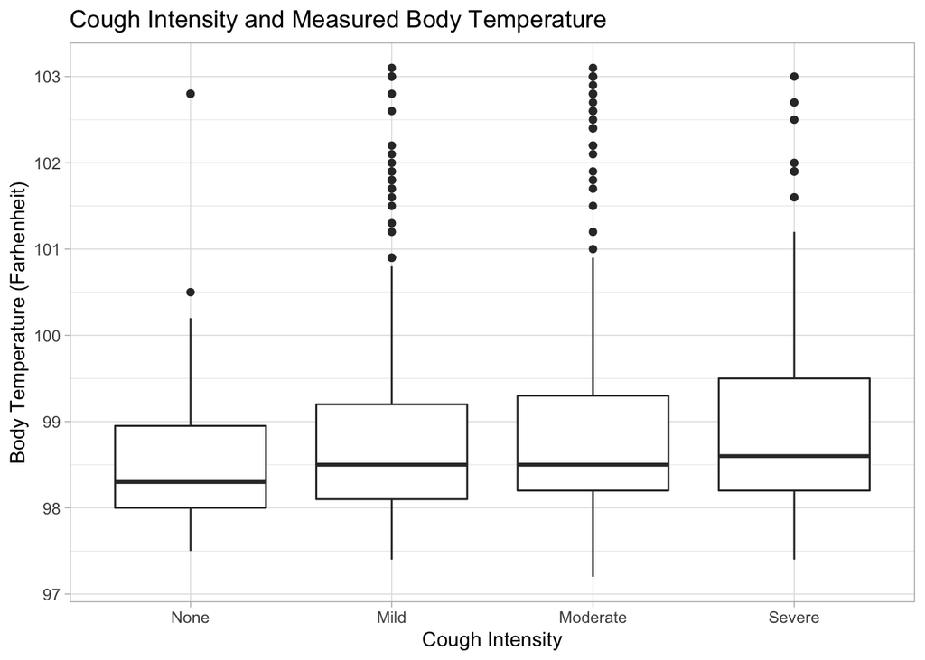

```r
#cough intensity and body temperature
ggplot(data, aes(x = CoughIntensity, y = BodyTemp)) +
  geom_boxplot() +
  labs(x = 'Cough Intensity', y = 'Body Temperature (Farhenheit)',
       title = 'Cough Intensity and Measured Body Temperature')
```

```r
#mean body temperatures across cough intensities
data %>%
  dplyr::group_by(CoughIntensity) %>%
  summarise(Count = n(),
            Mean_Body_Temp = mean(BodyTemp)) %>%
  kable(format = 'simple')
```

| CoughIntensity | Count | Mean_Body_Temp |
| --- | --- | --- |
| None | 47 | 98.65957 |
| Mild | 154 | 99.00000 |
| Moderate | 357 | 98.91541 |
| Severe | 172 | 98.99302 |

I wanted to look at cough intensity so I could have see at least one categorical variable with more than two response possibilities. This boxplot also matches what I expected from the summary table, which stated 47 had no cough, 154 had mild cough, 357 had moderate cough, and 172 had severe cough.

I also compared body temperature means across cough intensities, and did not see much difference. Those without a cough do seem to have a slightly lower mean temperature (but not by much), but the others are all very similar.

### Vomiting

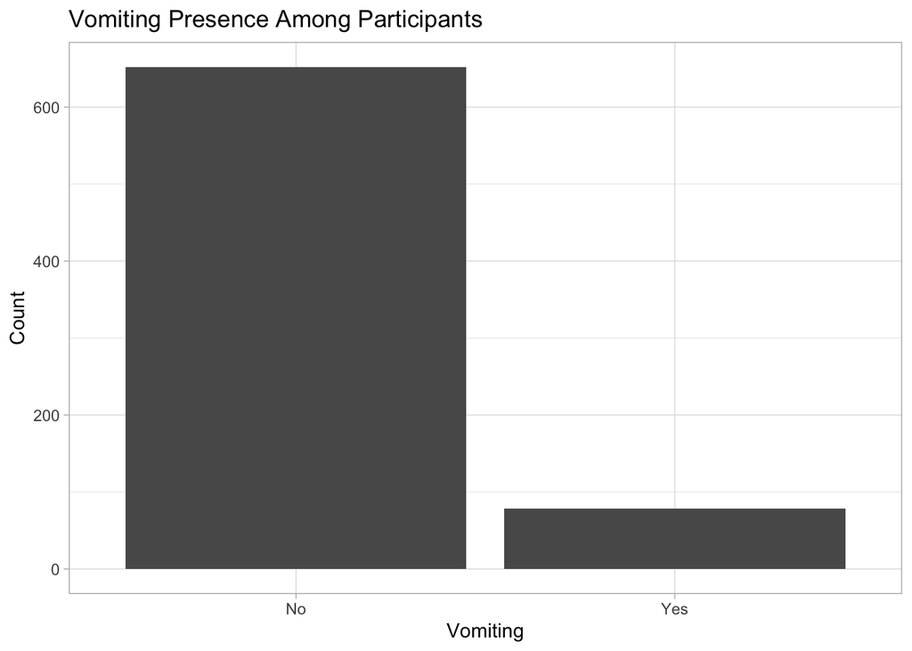

```r
#barplot of vomiting
ggplot(data = data, aes(x = Vomit)) +
  geom_bar() +
  labs(x = 'Vomiting', y = 'Count',
       title = 'Vomiting Presence Among Participants')
```

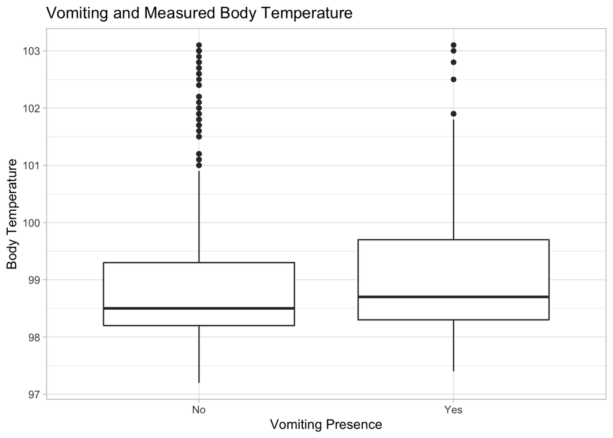

```r
#boxplot of runny nose versus body temperature
ggplot(data, aes(x = Vomit, y = BodyTemp)) +
  geom_boxplot() +
  labs(x = 'Vomiting Presence', y = 'Body Temperature',
       title = 'Vomiting and Measured Body Temperature')
```

```r
#mean body temp with and without vomiting
data %>%
  dplyr::group_by(Vomit) %>%
  summarise(Count = n(),
            Mean_Body_Temp = mean(BodyTemp)) %>%
  kable(format = 'simple')
```

| Vomit | Count | Mean_Body_Temp |
| --- | --- | --- |
| No | 652 | 98.90614 |
| Yes | 78 | 99.17692 |

Finally, I looked at vomiting. As with all the others, the boxplot matches the summary table, which stated 78 participants did have vomiting, and 652 did not.

I looked at body temperature means again, still without much difference. Those who had vomiting had a *very* slight higher mean temp, but just barely. This surprised me a little, as I would have expected vomiting and fever to go together more than it seems they do.